# Transit Trips and Transportation Costs – City

Author

Tina Chelidze and Aaron R. Williams

Published

March 21, 2025

Abstract

This script calculates `share_transportation_cost` and `share_transit_commuter` using Center for Neighborhood Technology (CNT) and Census Bureau data.

**Tip**

Raw CNT data pulled from https://htaindex.cnt.org/download/.

1. Navigate to the data download page.
2. Select “Tracts”.
3. Download the data for all tracts.

To save time, we store data on Box in Metrics_2024_round/. See details under the Read Data section.*

## Setup

### Load Packages

```r
library(tidyverse)
library(tidycensus)
library(here)

source(here("functions", "testing", "evaluate_final_data.R"))

theme_set(theme_bw())

options(scipen = 999)
```

### Read data

Before running, please download the entirety of the folders listed below from the following [Box folder](https://urbanorg.app.box.com/folder/250262697073) into the repository folder. You may be required to unzip the folders but keep the raw files in their folders. `"mobility-from-poverty/06_neighborhoods/Transportation/data/"`

- 2015_tract
- 2019_tract
- 2022_tract

Import all the files (and/or combine into one file) with only the relevant variables and years

```r
read_transportation_data <- function(year) {

  tractpath <- list.files(
    path = here("06_neighborhoods",
                "Transportation",
                "data",
                str_glue("{year}_tract")),
    pattern = "*.csv",
    full.names = TRUE
  )

  data <- map_dfr(tractpath, read_csv) |>
    mutate(year = year)

  return(data)

}

transportation_tracts <- map_dfr(
  .x = c(2015, 2019, 2022),
  .f = read_transportation_data
)
```

## Clean Data

Create correct FIPS columns.

```r
transportation_tracts <- transportation_tracts |>
  rename(GEOID = tract) |>
  mutate(
    state = substr(GEOID, start = 2, stop = 3),
    county = substr(GEOID, start = 4, stop = 6),
    tract = substr(GEOID, start = 7, stop = 12)
  )
```

```r
transportation_tracts <- transportation_tracts |>
  select(
    year, GEOID, state, county, tract, blkgrps, population, households,
    share_transit_commuter = pct_transit_commuters_80ami,
    share_transportation_cost = t_80ami
  )
```

```r
transportation_tracts <- transportation_tracts |>
  mutate(GEOID = paste0(state, county, tract))
```

Many tracts have no households. We drop these tracts.

```r
transportation_tracts <- transportation_tracts |>
  filter(households > 0)
```

We transform transportation cost from an unlabeled percentage to a proportion.

```r
transportation_tracts <- transportation_tracts |>
  mutate(
    share_transit_commuter = share_transit_commuter / 100,
    share_transportation_cost = share_transportation_cost / 100
  )
```

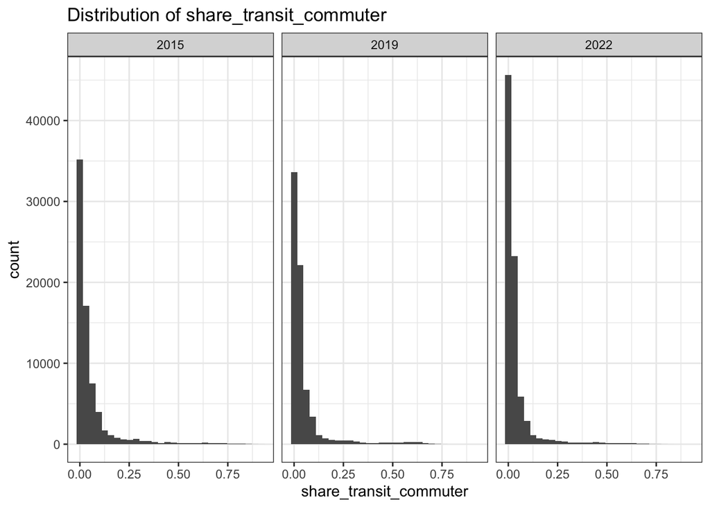

```r
transportation_tracts |>
  ggplot(aes(share_transit_commuter)) +
  geom_histogram() +
  facet_wrap(~ year) +
  labs(title = "Distribution of share_transit_commuter")
```

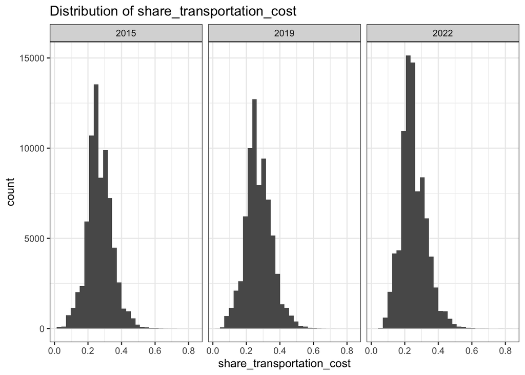

```r
transportation_tracts |>
  ggplot(aes(share_transportation_cost)) +
  geom_histogram() +
  facet_wrap(~ year) +
  labs(title = "Distribution of share_transportation_cost")
```

## Clean Census Data

We need to pull Census Bureau data to calculate data quality. We start by pulling `B25001_001`, which is the estimate and margin of error for the number of households in the tract.

```r
my_states <- fips_codes |>
  filter(!state %in% c("PR", "UM", "VI", "GU", "AS", "MP")) |>
  pull(state) |>
  unique()
```

```r
acs_sample_size <- bind_rows(
  `2015` = map_dfr(
    .x = my_states,
    .f = ~ get_acs(
      geography = "tract",
      state = .x,
      variables = c("B00002_001", "B25001_001"),
      year = 2015,
      survey = "acs5",
      output = "wide"
    )
  ),
  `2019` = map_dfr(
    .x = my_states,
    .f = ~ get_acs(
      geography = "tract",
      state = .x,
      variables = c("B25001_001"),
      year = 2019,
      survey = "acs5",
      output = "wide"
    )
  ),
  `2022` = map_dfr(
    .x = my_states,
    .f = ~ get_acs(
      geography = "tract",
      state = .x,
      variables = c("B25001_001"),
      year = 2022,
      survey = "acs5",
      output = "wide"
    )
  ),
  .id = "year"
) |>
  rename(
    sample_size = B00002_001E,
    households_est = B25001_001E,
    households_moe = B25001_001M
  ) |>
  mutate(
    year = as.numeric(year),
    state = str_sub(GEOID, start = 1, end = 2),
    county = str_sub(GEOID, start = 3, end = 5)
  )
```

Turn a 90% MOE into a standard error.

```r
acs_sample_size <- acs_sample_size |>
  mutate(
    households_se = households_moe / qnorm(0.95)
  )
```

`sample_size` is only pulled for exploratory uses.

```r
acs_sample_size <- acs_sample_size |>
  select(-sample_size)
```

After this, there shouldn’t be any missing values.

```r
stopifnot(
  all(map_dbl(acs_sample_size, ~sum(is.na(.x))) == 0)
)
```

We join the ACS quality information to the transportation information.

```r
transportation_tracts <- left_join(
  transportation_tracts,
  acs_sample_size,
  by = c("year", "GEOID", "state", "county"),
  relationship = "one-to-one"
)
```

## Crosswalk to Cities

Build a multi-year cross walk that uses 2010 and 2020 tract/place definitions.

```r
tract_place_crosswalk_2010s <- read_csv(
  here::here("geographic-crosswalks", "data", "geocorr2018_2010tract_to_2014place.csv")
) %>%
  rename(
    place = placefp,
    state_county = county
  ) %>%
  mutate(tract = tract * 100) |>
  mutate(
    state_county = str_pad(state_county, width = 5, side = "left", pad = "0"),
    state = str_sub(state_county, start = 1, end = 2),
    county = str_sub(state_county, start = 3, end = 5),
    tract = str_pad(tract, width = 6, side = "left", pad = "0"),
    place = str_pad(place, width = 5, side = "left", pad = "0")
  ) |>
  rename(population_crosswalk = pop10)

tract_place_crosswalk_2020s <- read_csv(
  here::here("geographic-crosswalks", "data", "geocorr2022_tract_to_place.csv")
) %>%
  rename(
    state_county = county
  ) %>%
  mutate(tract = tract * 100) |>
  mutate(
    state_county = str_pad(state_county, width = 5, side = "left", pad = "0"),
    state = str_sub(state_county, start = 1, end = 2),
    county = str_sub(state_county, start = 3, end = 5),
    tract = str_pad(tract, width = 6, side = "left", pad = "0"),
    place = str_pad(place, width = 5, side = "left", pad = "0")
  ) |>
  rename(population_crosswalk = pop20)

tract_place_crosswalk <- bind_rows(
  `2015` = tract_place_crosswalk_2010s,
  `2019` = tract_place_crosswalk_2010s,
  `2022` = tract_place_crosswalk_2020s,
  .id = "year"
) |>
  mutate(year = as.numeric(year)) |>
  select(year, state, county, tract, place, state_county, afact, population_crosswalk)
```

Limit to the Census Places we want.

```r
places <- read_csv(here("geographic-crosswalks",
                        "data",
                        "place-populations.csv")) |>
  filter(year %in% c(2015, 2019, 2022))
```

## Join and Aggregate

Joins are dangerous.

First, let’s see if all places in our target places file are present in the crosswalk. Only South Fulton, Georgia is missing in 2019.

```r
anti_join(
  places,
  tract_place_crosswalk,
  by = c("year", "state", "place")
)
```

```
# A tibble: 1 × 6
   year state place state_name place_name        population
  <dbl> <chr> <chr> <chr>      <chr>                  <dbl>
1  2019 13    72122 Georgia    South Fulton city      99155
```

Second let’s compare the aggregated population from the crosswalk to the populations in the places target geography file.

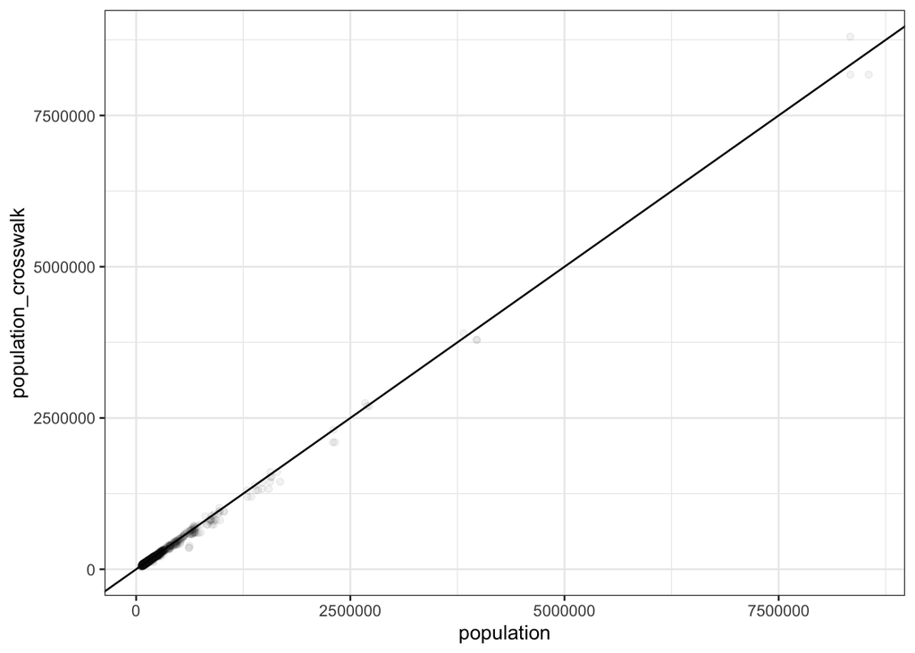

```r
full_join(
  places,
  tract_place_crosswalk |>
    group_by(year, state, place) |>
    summarize(population_crosswalk = sum(population_crosswalk)),
  by = c("year", "state", "place"),
  relationship = "one-to-one"
) |>
  ggplot(aes(population, population_crosswalk)) +
  geom_abline() +
  geom_point(alpha = 0.05)
```

Third let’s see if the CNT contain tracts not included in our places. Most of the missing tracts are Connecticut Planning Regions in the transportation data.

```r
# rows from transportation_tracts that are not in the crosswalk
anti_join(
  transportation_tracts,
  tract_place_crosswalk,
  by = c("state", "county", "tract")
) |>
  group_by(year, state, county) |>
  summarize(tracts = n(), households = sum(households), population = sum(population)) |>
  print(n = Inf)
```

```
# A tibble: 21 × 6
# Groups:   year, state [11]
    year state county tracts households population
   <dbl> <chr> <chr>   <int>      <dbl>      <dbl>
 1  2015 04    013         2         64        245
 2  2015 04    019         2       4434      14735
 3  2015 17    031         1        134        377
 4  2015 22    055         1          5         17
 5  2015 26    083         1          7         15
 6  2015 36    053         1       2645       7236
 7  2015 51    019         1       2675       6212
 8  2019 04    013         1       1289       4291
 9  2019 04    019         2       4849      15779
10  2019 17    031         1        129        434
11  2019 36    053         1       2583       7158
12  2019 51    019         1       2596       6449
13  2022 09    110       244     386549     975060
14  2022 09    120        78     117497     326381
15  2022 09    130        44      73084     175244
16  2022 09    140        98     177656     451887
17  2022 09    150        26      38574      95687
18  2022 09    160        37      45976     112696
19  2022 09    170       135     226154     571298
20  2022 09    180        66     113810     278986
21  2022 09    190       145     230507     620666
```

Finally, let’s join the crosswalk to the transportation data.

```r
transportation_tracts_places <- left_join(
  transportation_tracts,
  tract_place_crosswalk,
  by = c("year", "state", "county", "tract")
)

transportation_tracts_places <- transportation_tracts_places |>
  filter(!is.na(place))
```

Collapse to places and also create data quality marker data quality can be 1 when most of the tracts that fall in the place (e.g., >50% of the tracts) have most of their area falling in the place (e.g., >50% of the tract’s area is in the place) otherwise, data quality is 2.

```r
transportation_places <- transportation_tracts_places |>
  dplyr::group_by(year, state, place) |>
  dplyr::summarize(
    n = n(),
    share_transit_commuter = weighted.mean(share_transit_commuter, w = households * afact, na.rm = TRUE),
    share_transportation_cost = weighted.mean(share_transportation_cost, w = households * afact, na.rm = TRUE),
    households_est = sum(households_est * afact),
    households_se = sqrt(sum(households_se ^ 2)),
    match_pop = sum(population * afact),
    match_quality = weighted.mean(afact > 0.5, weight = households, na.rm = TRUE)
  ) |>
  ungroup()
```

Left join with places file to get rid of irrelevant places data

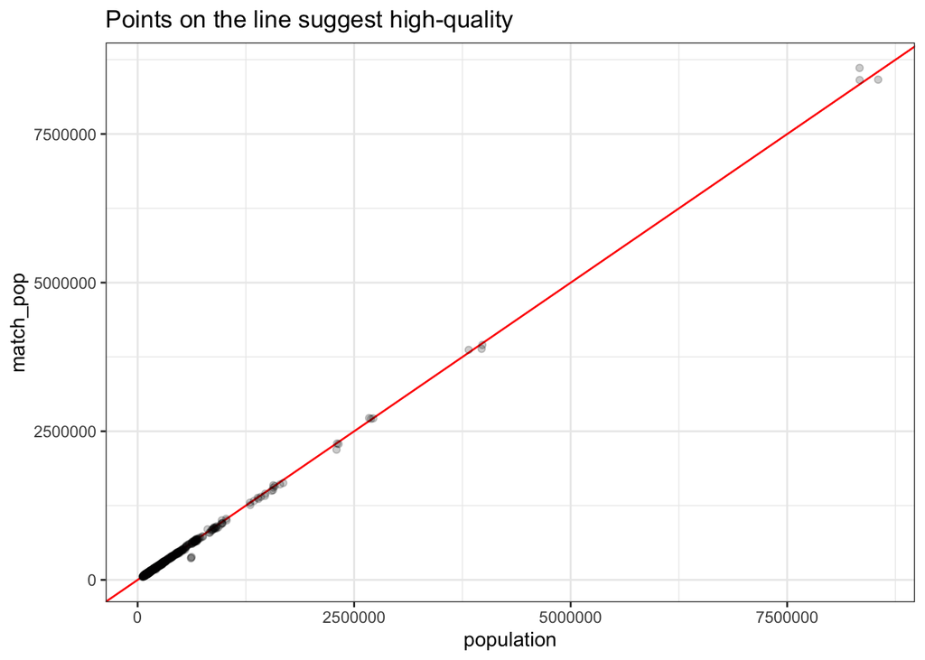

```r
transportation_city <- left_join(
  places,
  transportation_places,
  by = c("year", "state", "place")
) |>
  filter(year %in% c(2015, 2019, 2022))

transportation_city |>
  ggplot(aes(population, match_pop)) +
  geom_abline(color = "red") +
  geom_point(alpha = 0.2) +
  labs(
    title = "Points on the line suggest high-quality"
  )
```

```r
map_dbl(transportation_city, ~sum(is.na(.x)))
```

```
                     year                     state                     place
                        0                         0                         0
               state_name                place_name                population
                        0                         0                         0
                        n    share_transit_commuter share_transportation_cost
                        8                         8                         8
           households_est             households_se                 match_pop
                        8                         8                         8
            match_quality
                        8
```

## Transit Trips Quality Control Checks

### Missing Data

```r
transportation_city |>
  filter(is.na(share_transit_commuter))
```

```
# A tibble: 8 × 13
   year state place state_name  place_name        population     n
  <dbl> <chr> <chr> <chr>       <chr>                  <dbl> <int>
1  2019 13    72122 Georgia     South Fulton city      99155    NA
2  2022 09    08000 Connecticut Bridgeport city       148094    NA
3  2022 09    18430 Connecticut Danbury city           86433    NA
4  2022 09    37000 Connecticut Hartford city         119851    NA
5  2022 09    52000 Connecticut New Haven city        134932    NA
6  2022 09    55990 Connecticut Norwalk city           91390    NA
7  2022 09    73000 Connecticut Stamford city         136084    NA
8  2022 09    80000 Connecticut Waterbury city        114588    NA
# ℹ 6 more variables: share_transit_commuter <dbl>,
#   share_transportation_cost <dbl>, households_est <dbl>, households_se <dbl>,
#   match_pop <dbl>, match_quality <dbl>
```

### Distribution

Use stopifnot to check if all values in `transportation_city` are non-negative.

```r
stopifnot(min(transportation_city$share_transit_commuter, na.rm = TRUE) >= 0)
```

Create a histogram plot and summary stats for each dataframe check that all values are non-negative & count missing values examine outliers.

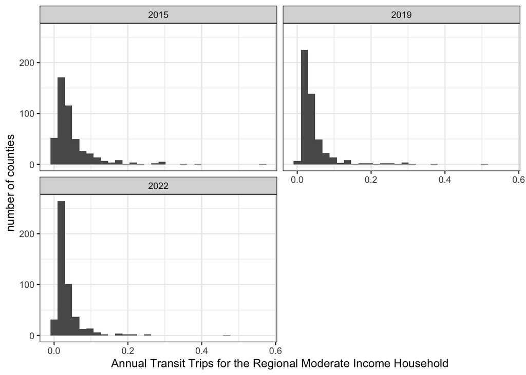

```r
ggplot(transportation_city, aes(x = share_transit_commuter)) +
  geom_histogram() +
  facet_wrap(~ year, nrow = 2) +
  labs(
    x = "Annual Transit Trips for the Regional Moderate Income Household",
    y = "number of counties"
  )
```

Look at summary stats

```r
summary(transportation_city$share_transit_commuter)
```

```
   Min. 1st Qu.  Median    Mean 3rd Qu.    Max.    NA's
0.00000 0.01802 0.02812 0.04328 0.04731 0.56504       8
```

Examine extreme values

```r
transportation_city |>
  group_by(year) |>
  slice_max(n = 10, order_by = share_transit_commuter)
```

```
# A tibble: 30 × 13
# Groups:   year [3]
    year state place state_name           place_name         population     n
   <dbl> <chr> <chr> <chr>                <chr>                   <dbl> <int>
 1  2015 36    51000 New York             New York city         8550405  2120
 2  2015 34    36000 New Jersey           Jersey City city       264290    66
 3  2015 06    67000 California           San Francisco city     864816   195
 4  2015 25    11000 Massachusetts        Cambridge city         110402    32
 5  2015 11    50000 District of Columbia Washington city        672228   179
 6  2015 17    14000 Illinois             Chicago city          2720546   797
 7  2015 25    07000 Massachusetts        Boston city            667137   171
 8  2015 25    62535 Massachusetts        Somerville city         80318    18
 9  2015 42    60000 Pennsylvania         Philadelphia city     1567442   376
10  2015 34    51000 New Jersey           Newark city            281944    85
# ℹ 20 more rows
# ℹ 6 more variables: share_transit_commuter <dbl>,
#   share_transportation_cost <dbl>, households_est <dbl>, households_se <dbl>,
#   match_pop <dbl>, match_quality <dbl>
```

### Change

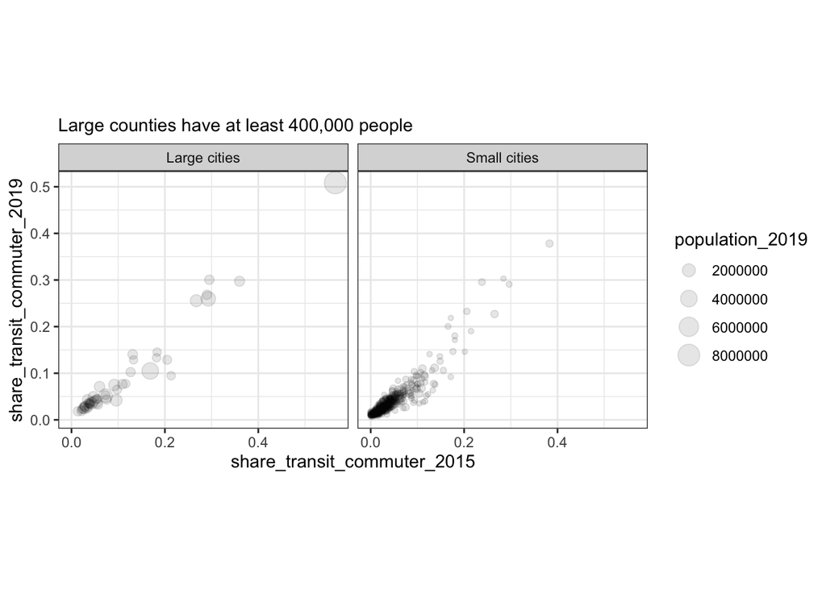

```r
transportation_city |>
  filter(year %in% c(2015, 2019)) |>
  select(state, place, year, population, share_transit_commuter) |>
  pivot_wider(
    names_from = year,
    values_from = c(population, share_transit_commuter)
  ) |>
  mutate(size = if_else(population_2019 > 400000, "Large cities", "Small cities")) |>
  ggplot(aes(share_transit_commuter_2015, share_transit_commuter_2019, size = population_2019)) +
  geom_point(alpha = 0.1) +
  facet_wrap(~ size) +
  coord_equal() +
  labs(subtitle = "Large counties have at least 400,000 people")
```

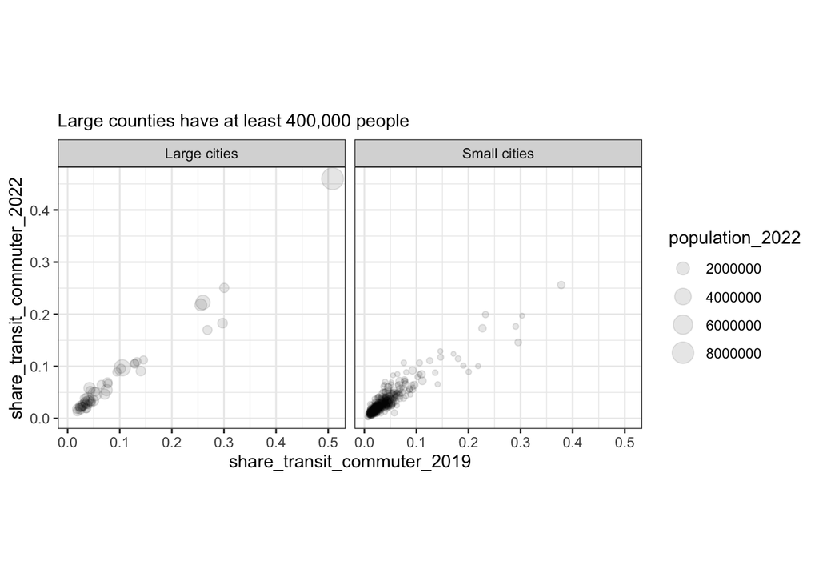

```r
transportation_city |>
  filter(year %in% c(2019, 2022)) |>
  select(state, place, year, population, share_transit_commuter) |>
  pivot_wider(
    names_from = year,
    values_from = c(population, share_transit_commuter)
  ) |>
  mutate(size = if_else(population_2022 > 400000, "Large cities", "Small cities")) |>
  ggplot(aes(share_transit_commuter_2019, share_transit_commuter_2022, size = population_2022)) +
  geom_point(alpha = 0.1) +
  facet_wrap(~ size) +
  coord_equal() +
  labs(subtitle = "Large counties have at least 400,000 people")
```

```r
transportation_city |>
  group_by(year, state, place) |>
  mutate(change = share_transit_commuter - lag(share_transit_commuter)) |>
  ungroup() |>
  filter(year %in% c(2019, 2022)) |>
  slice_max(order_by = abs(change), n = 10)
```

```
# A tibble: 972 × 14
    year state place state_name place_name             population     n
   <dbl> <chr> <chr> <chr>      <chr>                       <dbl> <int>
 1  2019 01    03076 Alabama    Auburn city                 66259    16
 2  2019 01    07000 Alabama    Birmingham city            209403    98
 3  2019 01    35896 Alabama    Hoover city                 85768    29
 4  2019 01    37000 Alabama    Huntsville city            200574    65
 5  2019 01    50000 Alabama    Mobile city                188720    77
 6  2019 01    51000 Alabama    Montgomery city            198525    61
 7  2019 01    77256 Alabama    Tuscaloosa city            101129    38
 8  2019 02    03000 Alaska     Anchorage municipality     288000    55
 9  2019 04    04720 Arizona    Avondale city               87931    23
10  2019 04    07940 Arizona    Buckeye city                79620    14
# ℹ 962 more rows
# ℹ 7 more variables: share_transit_commuter <dbl>,
#   share_transportation_cost <dbl>, households_est <dbl>, households_se <dbl>,
#   match_pop <dbl>, match_quality <dbl>, change <dbl>
```

## Cost Quality Control Checks

### Missing Data

```r
transportation_city |>
  filter(is.na(share_transportation_cost))
```

```
# A tibble: 8 × 13
   year state place state_name  place_name        population     n
  <dbl> <chr> <chr> <chr>       <chr>                  <dbl> <int>
1  2019 13    72122 Georgia     South Fulton city      99155    NA
2  2022 09    08000 Connecticut Bridgeport city       148094    NA
3  2022 09    18430 Connecticut Danbury city           86433    NA
4  2022 09    37000 Connecticut Hartford city         119851    NA
5  2022 09    52000 Connecticut New Haven city        134932    NA
6  2022 09    55990 Connecticut Norwalk city           91390    NA
7  2022 09    73000 Connecticut Stamford city         136084    NA
8  2022 09    80000 Connecticut Waterbury city        114588    NA
# ℹ 6 more variables: share_transit_commuter <dbl>,
#   share_transportation_cost <dbl>, households_est <dbl>, households_se <dbl>,
#   match_pop <dbl>, match_quality <dbl>
```

### Distribution

Use stopifnot to check if all values in `transportation_city` are non-negative

```r
stopifnot(min(transportation_city$share_transportation_cost, na.rm = TRUE) >= 0)
```

Create a histogram plot and summary stats for each dataframe check that all values are non-negative & count missing values examine outliers.

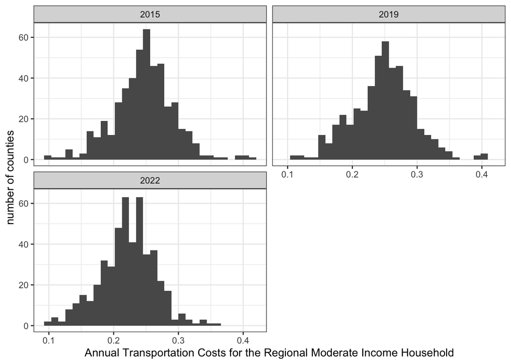

```r
ggplot(transportation_city, aes(x = share_transportation_cost)) +
  geom_histogram() +
  facet_wrap(~ year, nrow = 2) +
  labs(
    x = "Annual Transportation Costs for the Regional Moderate Income Household",
    y = "number of counties"
  )
```

Makes sense for most counties to fall in really low transit trip numbers since most of the US has no public infrastructure that can be used for daily transport

Look at summary stats

```r
summary(transportation_city$share_transportation_cost)
```

```
   Min. 1st Qu.  Median    Mean 3rd Qu.    Max.    NA's
0.09969 0.20966 0.24093 0.23861 0.26775 0.41604       8
```

Examine extreme values

```r
transportation_city |>
  group_by(year) |>
  slice_max(n = 10, order_by = share_transportation_cost)
```

```
# A tibble: 30 × 13
# Groups:   year [3]
    year state place state_name place_name       population     n
   <dbl> <chr> <chr> <chr>      <chr>                 <dbl> <int>
 1  2015 48    48768 Texas      Mission city          83298    16
 2  2015 48    22660 Texas      Edinburg city         84497    13
 3  2015 48    57200 Texas      Pharr city            76538     9
 4  2015 48    45384 Texas      McAllen city         140269    28
 5  2015 48    10768 Texas      Brownsville city     183887    50
 6  2015 06    82954 California Visalia city         130104    23
 7  2015 48    41464 Texas      Laredo city          255473    58
 8  2015 06    46898 California Merced city           82436    20
 9  2015 06    14218 California Clovis city          104180    25
10  2015 12    54200 Florida    Palm Coast city       82893    16
# ℹ 20 more rows
# ℹ 6 more variables: share_transit_commuter <dbl>,
#   share_transportation_cost <dbl>, households_est <dbl>, households_se <dbl>,
#   match_pop <dbl>, match_quality <dbl>
```

### Change

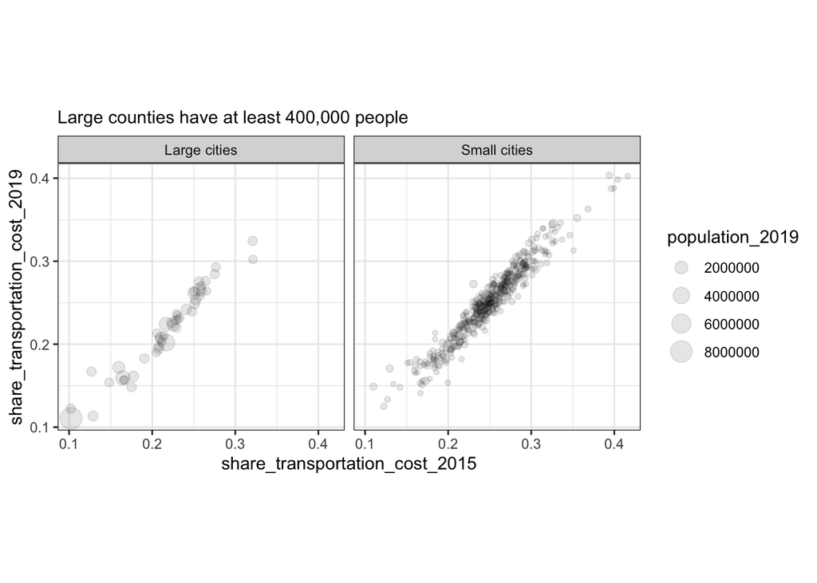

```r
transportation_city |>
  filter(year %in% c(2015, 2019)) |>
  select(state, place, year, population, share_transportation_cost) |>
  pivot_wider(
    names_from = year,
    values_from = c(population, share_transportation_cost)
  ) |>
  mutate(size = if_else(population_2019 > 400000, "Large cities", "Small cities")) |>
  ggplot(aes(share_transportation_cost_2015, share_transportation_cost_2019, size = population_2019)) +
  geom_point(alpha = 0.1) +
  facet_wrap(~ size) +
  coord_equal() +
  labs(subtitle = "Large counties have at least 400,000 people")
```

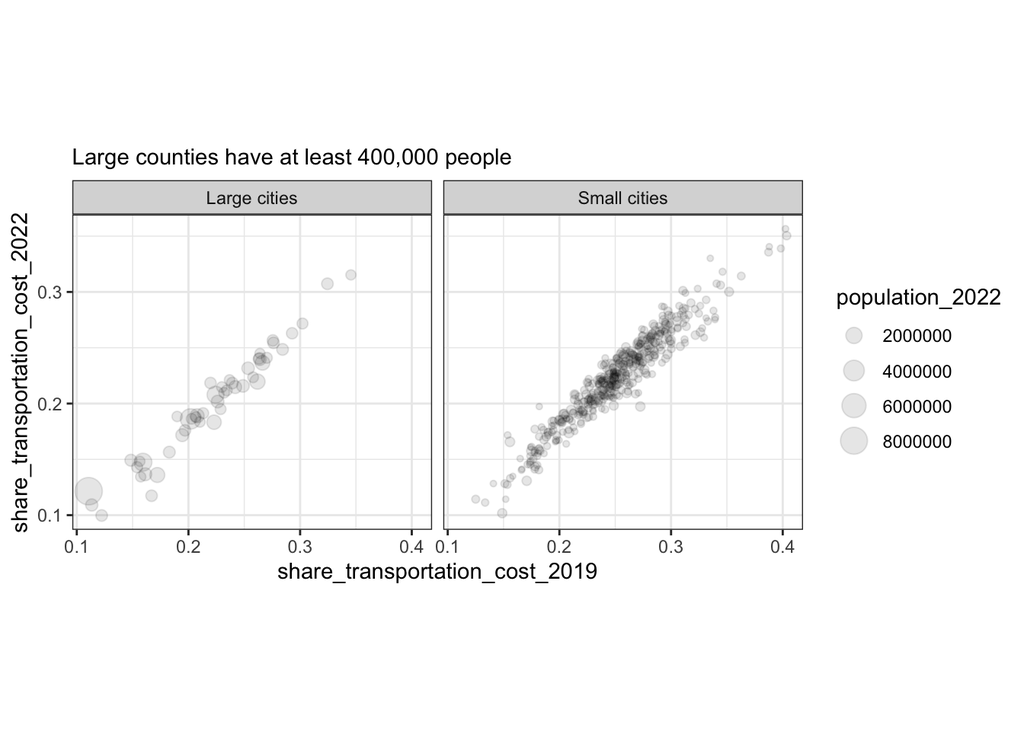

```r
transportation_city |>
  filter(year %in% c(2019, 2022)) |>
  select(state, place, year, population, share_transportation_cost) |>
  pivot_wider(
    names_from = year,
    values_from = c(population, share_transportation_cost)
  ) |>
  mutate(size = if_else(population_2022 > 400000, "Large cities", "Small cities")) |>
  ggplot(aes(share_transportation_cost_2019, share_transportation_cost_2022, size = population_2022)) +
  geom_point(alpha = 0.1) +
  facet_wrap(~ size) +
  coord_equal() +
  labs(subtitle = "Large counties have at least 400,000 people")
```

```r
transportation_city |>
  group_by(year, state, place) |>
  mutate(change = share_transportation_cost - lag(share_transportation_cost)) |>
  ungroup() |>
  filter(year %in% c(2019, 2022)) |>
  slice_max(order_by = abs(change), n = 10)
```

```
# A tibble: 972 × 14
    year state place state_name place_name             population     n
   <dbl> <chr> <chr> <chr>      <chr>                       <dbl> <int>
 1  2019 01    03076 Alabama    Auburn city                 66259    16
 2  2019 01    07000 Alabama    Birmingham city            209403    98
 3  2019 01    35896 Alabama    Hoover city                 85768    29
 4  2019 01    37000 Alabama    Huntsville city            200574    65
 5  2019 01    50000 Alabama    Mobile city                188720    77
 6  2019 01    51000 Alabama    Montgomery city            198525    61
 7  2019 01    77256 Alabama    Tuscaloosa city            101129    38
 8  2019 02    03000 Alaska     Anchorage municipality     288000    55
 9  2019 04    04720 Arizona    Avondale city               87931    23
10  2019 04    07940 Arizona    Buckeye city                79620    14
# ℹ 962 more rows
# ℹ 7 more variables: share_transit_commuter <dbl>,
#   share_transportation_cost <dbl>, households_est <dbl>, households_se <dbl>,
#   match_pop <dbl>, match_quality <dbl>, change <dbl>
```

## Data Quality Marker

We calculate data quality using the coefficient of variation for the number of households, coefficient of variation for median household income, and match quality. We use the “worst” data quality from these three tests.

Elsewhere, we use 0.2 and 0.4 as cutoffs for the coefficient of variation. These metrics contain extra uncertainty from other variables and modelings, so we use 0.08 and 0.15 as cutoffs.

```r
transportation_city <- transportation_city |>
  mutate(households_cv = households_se / households_est) |>
  dplyr::mutate(
    cv_quality = case_when(
      households_cv < 0.08 ~ 1,
      households_cv < 0.15 ~ 2,
      TRUE ~ 3
    ),
    match_quality = case_when(
      match_quality >= 0.5 ~ 1,
      match_quality < 0.5 ~ 2,
      TRUE ~ NA
    )
  )
```

Next, we load and calculate the coefficient of variation for median household income at the place level.

```r
med_hh_income_cv <- bind_rows(
  `2015` = get_acs(
    geography = "place",
    variables = "B19013_001",
    year = 2015,
    survey = "acs5",
    output = "wide"
  ),
  `2019` = get_acs(
    geography = "place",
    variables = "B19013_001",
    year = 2019,
    survey = "acs5",
    output = "wide"
  ),
  `2022` = get_acs(
    geography = "place",
    variables = "B19013_001",
    year = 2022,
    survey = "acs5",
    output = "wide"
  ),
  .id = "year"
) |>
  rename(
    med_hh_income = B19013_001E,
    med_hh_income_moe = B19013_001M,
  ) |>
  mutate(
    year = as.numeric(year),
    state = str_sub(GEOID, start = 1, end = 2),
    place = str_sub(GEOID, start = 3, end = 7)
  )

med_hh_income_cv <- med_hh_income_cv |>
  mutate(med_hh_income_se = med_hh_income_moe / qnorm(0.95)) |>
  # calculate the coefficient of variation
  mutate(med_hh_income_cv = med_hh_income_se / med_hh_income) |>
  mutate(med_hh_income_cv = ifelse(is.na(med_hh_income_cv), 0.5, med_hh_income_cv)) |>
  mutate(
    income_quality = case_when(
      med_hh_income_cv < 0.1 ~ 1,
      med_hh_income_cv < 0.3 ~ 2,
      TRUE ~ 3
    )
  ) |>
  select(year, state, place, income_quality)
```

We use the worse quality of the 1. household estimates CV, 2. median household income CV, and 3. match quality CV.

```r
transportation_city <- left_join(
  transportation_city,
  med_hh_income_cv,
  by = c("year", "state", "place")
)

transportation_city <- transportation_city |>
  mutate(
    share_transit_commuter_quality = pmax(cv_quality, income_quality, match_quality),
    share_transportation_cost_quality = pmax(cv_quality, income_quality, match_quality)
  ) |>
  mutate(
    share_transit_commuter_quality =
      ifelse(is.na(share_transit_commuter), NA, share_transit_commuter_quality),
    share_transportation_cost_quality =
      ifelse(is.na(share_transportation_cost_quality), NA, share_transportation_cost_quality)
  )
```

```r
transportation_city |>
  count(year, share_transit_commuter_quality)
```

```
# A tibble: 7 × 3
   year share_transit_commuter_quality     n
  <dbl>                          <dbl> <int>
1  2015                              1   484
2  2015                              2     1
3  2019                              1   484
4  2019                              2     1
5  2019                             NA     1
6  2022                              1   479
7  2022                             NA     7
```

Confirm there isn’t a mismatch between missing values and missing quality flags.

```r
stopifnot(
  transportation_city |>
    filter(
      (!is.na(share_transit_commuter) & is.na(share_transit_commuter_quality)) |
        (!is.na(share_transportation_cost) & is.na(share_transportation_cost_quality))
    ) |>
    nrow() == 0
)

stopifnot(
  transportation_city |>
    filter(
      (is.na(share_transit_commuter) & !is.na(share_transit_commuter_quality)) |
        (is.na(share_transportation_cost) & !is.na(share_transportation_cost_quality))
    ) |>
    nrow() == 0
)
```

## Export final files

Keep variables of interest and order them appropriately.

```r
final_data <- transportation_city |>
  select(
    year, state, place, share_transit_commuter, share_transit_commuter_quality,
    share_transportation_cost, share_transportation_cost_quality
  ) |>
  arrange(year, state, place)
```

Run the evaluation function.

```r
evaluate_final_data(
  exp_form_path = here("10a_final-evaluation", "evaluation_form_transportation_city.csv"),
  data = final_data,
  geography = "place",
  confidence_intervals = FALSE
)
```

```
[1] "This data passes all tests!"
```

Write the final data.

```r
final_data |>
  write_csv(
    here("06_neighborhoods",
         "Transportation",
         "final",
         "transportation_all_city.csv")
  )
```